# Assignment2Group9

Rasmus

9 November 2015

By looking at the crowdsourced data, there are a number of issues that should be considered. We can get a snap-shot of the reported bribe,but more rigourous data collecting is needed in order to make sound statstical inference on the subject. The data is extracted from the 1000 latest entries of data. In this data there are reported entires for the dates November 5-8th 2015. Another sample period might have given different results, as interactions with public authorities may be have difference frequencies a cross time, i.e. an end-of-month tax collection. This can also vary geographically. However, there may also be a lag in time from the incident of bribe to reporting it.

There is an altruistic incentive to frequently report bribes in order to combat wide-spread corruption in India. However, it is not possible to penalize false reporters. Civilians may report certain classes of incidents with a larger propensity than others.

We start by initializing the relevant packages for scraping the webpage *www.ipaidabribe.com*

```r
library("rvest")
#<<<<<<< Updated upstream
library(stringr)
#=======
library("stringr")
#>>>>>>> Stashed changes
```

We want the lates 1.000 observations and since the webpage is designed such that 10 observations are on each page, we need to scrape 100 pages. The first page looks like this:

```r
link = "http://www.ipaidabribe.com/reports/paid?page="
```

We let R loop from 00 to 1000 with steps of 10 and define the variables of interest:

- Title
- Amount paid
- Name of the bribed person/institution
- Type of transaction
- Number of views
- City and region
- Date

The scraped data is first stored in a list and then converted to a dataframe using the plyr package.

[output not shown]

[output not shown]

[output cut: 45 more lines]

[output not shown]

We do some data cleaning to isolate the numeric part in the amount and view variables using *str_exstract*.

```r
df.bribe$my.link.amount_text = str_extract(df.bribe$my.link.amount_text,"[0,0-9,9]+")
df.bribe$my.link.views = str_extract(df.bribe$my.link.views,"[0,0-9,9]+")

df.bribe=data.frame(page=df.bribe$.id, title=df.bribe$my.link.title, amount=df.bribe$my.link.amount_text, name=df.bribe$my.link.name, transaction=df.bribe$my.link.transaction, views=df.bribe$my.link.views, city=df.bribe$my.link.city, date=df.bribe$my.link.date)

library("dplyr")
library("lubridate")

df.bribe$amount = as.numeric(str_replace_all(df.bribe$amount, pattern = "," , replacement = ""))
#filter out outliers
df.bribe=filter(df.bribe,df.bribe$amount<3000000 )
df.bribe$views = as.numeric(df.bribe$views)
```

More data cleaning is done when we extract the city and the region from the combined variable we got from scraping.

```r
df.bribe$city1 = str_extract(df.bribe$city,"[A-z]*")

df.bribe$reg = str_extract(df.bribe$city,", [A-z]+ [A-z]+")
df.bribe$reg1 = str_extract(df.bribe$city,", [A-z]+")
df.bribe$reg=gsub(",","", df.bribe$reg)
df.bribe$reg1=gsub(",","", df.bribe$reg1)

df.bribe$reg2[is.na(df.bribe$reg)]=df.bribe$reg1[is.na(df.bribe$reg)]
df.bribe$reg2[is.na(df.bribe$reg2)]=df.bribe$reg[is.na(df.bribe$reg2)]
df.bribe$reg=df.bribe$reg2

class(df.bribe$amount)
```

```
## [1] "numeric"
```

```r
df.bribe$antal=1
```

```r
# stat data for cities
df.bribe.reg = df.bribe %>%
  group_by(reg) %>%
  summarise(antal = sum(antal), median_amount = median(amount), mean_views = mean(views) ) %>%
  arrange(desc(median_amount)) %>%
  data.frame

# stat data for name
df.bribe.name = df.bribe %>%
  group_by(name) %>%
  summarise(antal = sum(antal), median_amount = median(amount), mean_views = mean(views) ) %>%
  arrange(desc(median_amount)) %>%
  data.frame

# stat data for transaction
df.bribe.transaction = df.bribe %>%
  group_by(transaction) %>%
  summarise(antal = sum(antal), median_amount = median(amount), mean_views = mean(views) ) %>%
  arrange(desc(median_amount)) %>%
  data.frame
```

We use *ggplot2* package to do graphs.

```r
library("ggplot2")
```

Our first graph shows the median amount paid in bribe across regions. Some regions might have a higher reported bribe-amount which may come from either more corruption or more people who like to report in these specific areas.

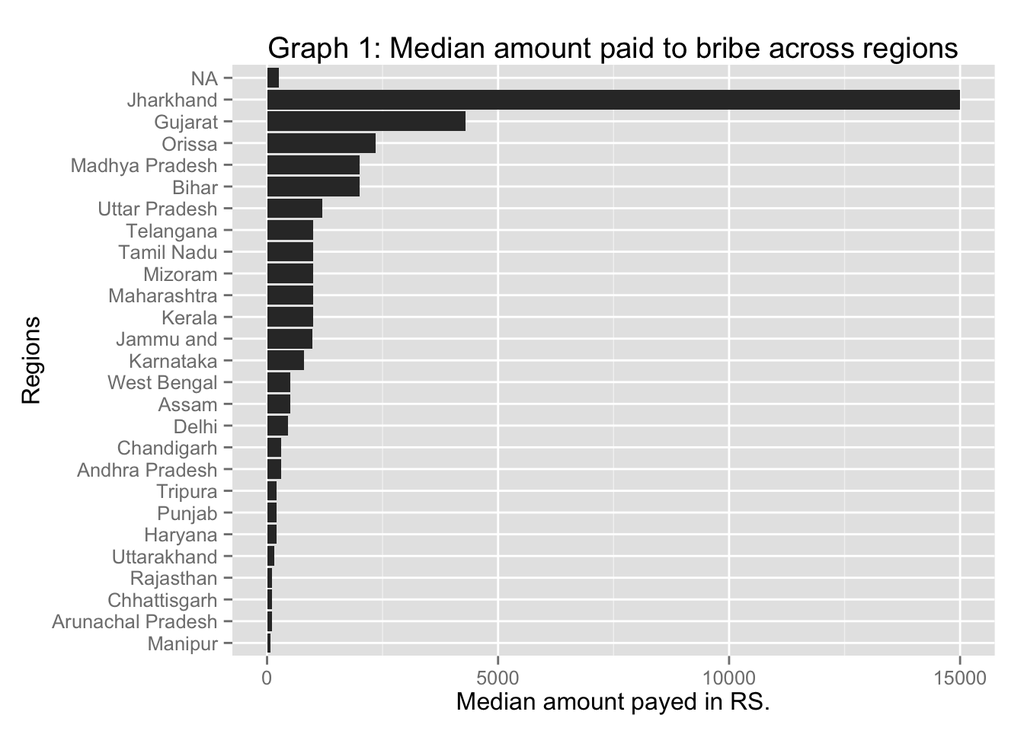

```r
p = ggplot(df.bribe.reg, aes(x = reorder(reg, median_amount),
                             y = median_amount))
p = p + geom_bar(stat = "identity") + coord_flip() + labs(title="Graph 1: Median amount paid to bribe across regions", x="Regions", y="Median amount payed in RS.")
plot(p)
```

The next graph shows the median amount paid in bribe for each department. Again some departments might be associated with higher corruption levels.

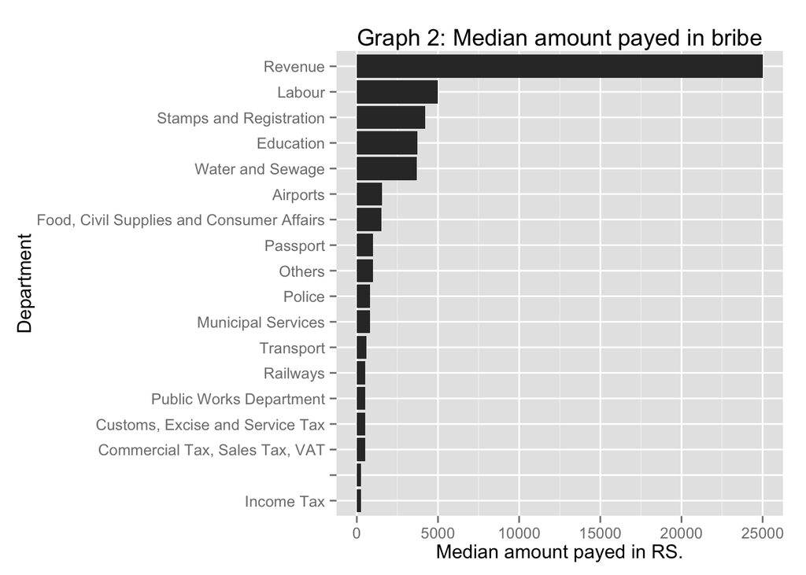

```r
#plot 2
p = ggplot(df.bribe.name, aes(x = reorder(name, median_amount),
                              y = median_amount))
p = p + geom_bar(stat = "identity") + coord_flip() + labs(title="Graph 2: Median amount payed in bribe", x="Department", y="Median amount payed in RS.")
plot(p)
```

Here we have instead the number of bribes for each department.

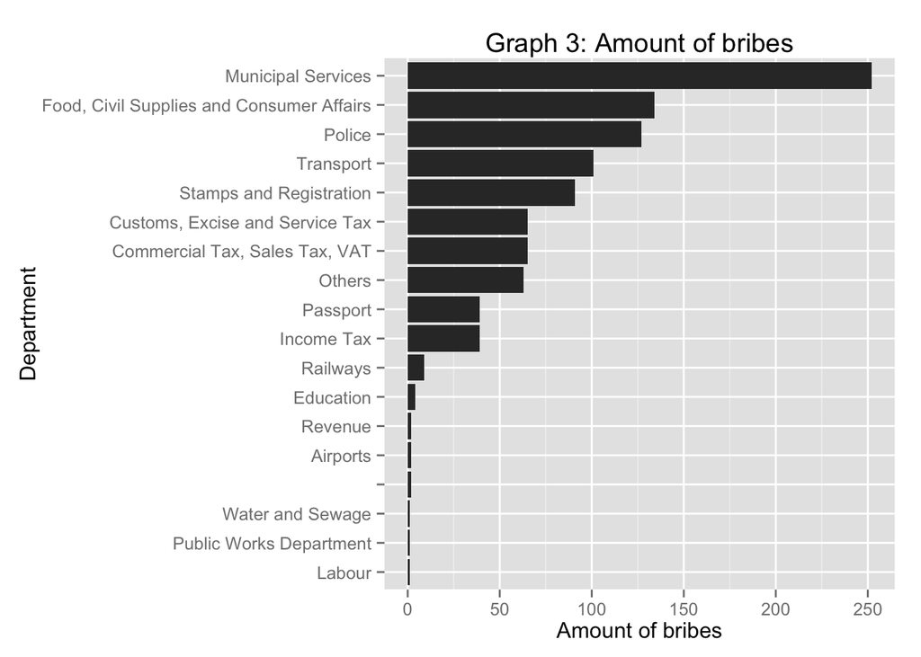

```r
p = ggplot(df.bribe.name, aes(x = reorder(name, antal),
                              y = antal))
p = p + geom_bar(stat = "identity") + coord_flip() + labs(title="Graph 3: Amount of bribes", x="Department", y="Amount of bribes")
plot(p)
```

Wondering if there is any correlation between the frequency of each transaction type we plot these together.

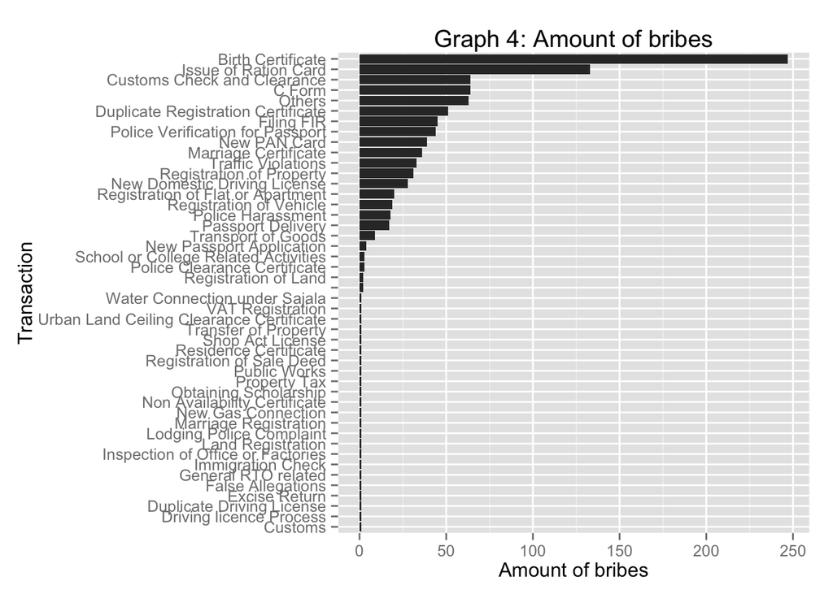

```r
p = ggplot(df.bribe.transaction, aes(x = reorder(transaction, antal),
                                     y = antal))
p = p + geom_bar(stat = "identity") + coord_flip() + labs(title="Graph 4: Amount of bribes", x="Transaction", y="Amount of bribes")
plot(p)
```

Our last graph shows the median amount paid in bribe across different transactions.

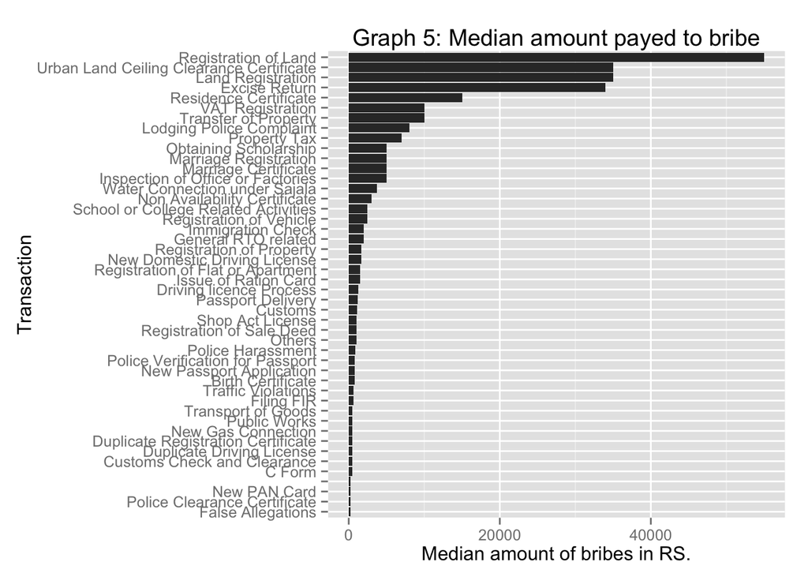

```r
p = ggplot(df.bribe.transaction, aes(x = reorder(transaction, median_amount),
                                     y = median_amount))
p = p + geom_bar(stat = "identity") + coord_flip() + labs(title="Graph 5: Median amount payed to bribe", x="Transaction", y="Median amount of bribes in RS.")
plot(p)
```